# lazarte_CS101

Ryan Rainzor A. Lazarte

2026-11-04

## Part A - Creating Data Frames

Question #1

1. The table below shows the data about shoe size and height. Create a data frame. Save it as shoesize.csv

```r
shoesize <- data.frame(
  Shoe_size = c(6.5, 9.0, 8.5, 8.5, 10.5, 7.0, 9.5, 9.0, 13.0, 7.5, 10.5, 8.5, 12.0, 10.5,13.0, 11.5, 8.5, 5.0, 10.0, 6.5, 7.5, 8.5, 10.5, 8.5, 10.5, 11.0, 9.0, 13.0),
  Height = c(66.0, 68.0, 64.5, 65.0, 70.0, 64.0, 70.0, 71.0, 72.0, 64.0, 74.5, 67.0, 71.0, 71.0,77.0, 72.0, 59.0, 62.0, 72.0, 66.0, 64.0, 67.0, 73.0, 69.0, 72.0, 70.0, 69.0, 70.0),
  Gender = c("F","F","F","F","M","F","F","F","M","F","M","F","M","M","M","M","F","F","M","F","F","M","M","F","M","M","M","M")
)
write.csv(shoesize, "shoesize.csv", row.names = FALSE)
```

2. Then try to import the saved csv into the R environment. Display the last 5 rows.

```r
shoes <- read.csv("shoesize.csv")
tail(shoes, 5)
```

```
##    Shoe_size Height Gender
## 24       8.5     69      F
## 25      10.5     72      M
## 26      11.0     70      M
## 27       9.0     69      M
## 28      13.0     70      M
```

3. Describe the data by showing the structures and its content.

```r
str(shoes)
```

```
## 'data.frame':    28 obs. of  3 variables:
##  $ Shoe_size: num  6.5 9 8.5 8.5 10.5 7 9.5 9 13 7.5 ...
##  $ Height   : num  66 68 64.5 65 70 64 70 71 72 64 ...
##  $ Gender   : chr  "F" "F" "F" "F" ...
```

```r
summary(shoes)
```

```
##    Shoe_size          Height            Gender
##  Min.   : 5.000   Min.   :59.00   Length   :28
##  1st Qu.: 8.500   1st Qu.:65.75   N.unique : 2
##  Median : 9.000   Median :69.50   N.blank  : 0
##  Mean   : 9.411   Mean   :68.57   Min.nchar: 1
##  3rd Qu.:10.500   3rd Qu.:71.25   Max.nchar: 1
##  Max.   :13.000   Max.   :77.00
```

```r
head(shoes)
```

```
##   Shoe_size Height Gender
## 1       6.5   66.0      F
## 2       9.0   68.0      F
## 3       8.5   64.5      F
## 4       8.5   65.0      F
## 5      10.5   70.0      M
## 6       7.0   64.0      F
```

4. Inspect its dimensions. How many rows? How about columns?

```r
dim(shoes)
```

```
## [1] 28  3
```

```r
nrow(shoes)
```

```
## [1] 28
```

```r
ncol(shoes)
```

```
## [1] 3
```

5. Inspect by using summary(). What is the difference of the summary() from str() function?

```r
summary(shoes)
```

```
##    Shoe_size          Height            Gender
##  Min.   : 5.000   Min.   :59.00   Length   :28
##  1st Qu.: 8.500   1st Qu.:65.75   N.unique : 2
##  Median : 9.000   Median :69.50   N.blank  : 0
##  Mean   : 9.411   Mean   :68.57   Min.nchar: 1
##  3rd Qu.:10.500   3rd Qu.:71.25   Max.nchar: 1
##  Max.   :13.000   Max.   :77.00
```

```r
str(shoes)
```

```
## 'data.frame':    28 obs. of  3 variables:
##  $ Shoe_size: num  6.5 9 8.5 8.5 10.5 7 9.5 9 13 7.5 ...
##  $ Height   : num  66 68 64.5 65 70 64 70 71 72 64 ...
##  $ Gender   : chr  "F" "F" "F" "F" ...
```

Summary presents the data of mean, min, max, the length, and the median of the data which is quite similar to a statistical analysis. On the other hand, str() function provides numerical data for the matrix.

6. Create a subset by males and females with their corresponding shoe size and height. What its result? Show the R scripts.

```r
males   <- shoes[shoes$Gender == "M",c("Shoe_size", "Height")]
females <- shoes[shoes$Gender == "F", c("Shoe_size", "Height")]
males
```

```
##    Shoe_size Height
## 5       10.5   70.0
## 9       13.0   72.0
## 11      10.5   74.5
## 13      12.0   71.0
## 14      10.5   71.0
## 15      13.0   77.0
## 16      11.5   72.0
## 19      10.0   72.0
## 22       8.5   67.0
## 23      10.5   73.0
## 25      10.5   72.0
## 26      11.0   70.0
## 27       9.0   69.0
## 28      13.0   70.0
```

```r
females
```

```
##    Shoe_size Height
## 1        6.5   66.0
## 2        9.0   68.0
## 3        8.5   64.5
## 4        8.5   65.0
## 6        7.0   64.0
## 7        9.5   70.0
## 8        9.0   71.0
## 10       7.5   64.0
## 12       8.5   67.0
## 17       8.5   59.0
## 18       5.0   62.0
## 20       6.5   66.0
## 21       7.5   64.0
## 24       8.5   69.0
```

7. Find the mean of shoe size and height of the respondents. Write the R scripts and its result.

```r
mean(shoes$Shoe_size, na.rm = TRUE)
```

```
## [1] 9.410714
```

```r
mean(shoes$Height, na.rm = TRUE)
```

```
## [1] 68.57143
```

8. Is there a relationship between shoe size and height? Why?

```r
cor(shoes$Shoe_size, shoes$Height)
```

```
## [1] 0.7766089
```

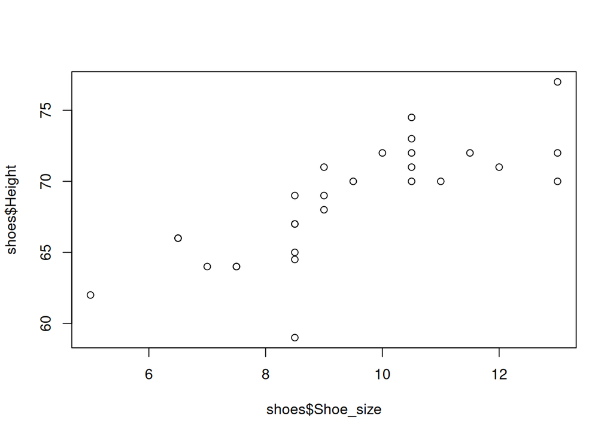

```r
plot(shoes$Shoe_size, shoes$Height)
```

Question #2:

```r
shoes$Gender <- factor(shoes$Gender)
levels(shoes$Gender)
```

```
## [1] "F" "M"
```

Question #3

Knitting always starts from the .Rmd file’s own folder, so a relative path like read.csv(“shoes.csv”) works on anyone’s computer as long as the files sit together. If it depended on your console’s working directory (or a hard-coded path like C:/Users/Ryan/…), it would break on another machine because that folder wouldn’t exist or would be different. This makes the document reproducible without anyone editing paths.

Question #4

Gender will most likely show as chr (character), not a factor. That’s expected, since R doesn’t convert text to factors automatically anymore, which is why Q2 asks you to do it yourself.If Shoe_Size were imported as chr because of a stray value like “N/A” or “9.5”, the mean() will return NA with warning, and arithmetic gives “non-numeric argument” errors. While, the cor() fails, and plots treat values as categories, sorted into alphabetically.

Question #5

head() only shows the first rows, so it can miss problems at the end of the file: extra footer or summary lines, trailing blank or junk rows, a truncated import, or a stray non-numeric value in the last rows. tail() shows the end, so checking both confirms the whole file came in cleanly, with the right number of rows.

Question #6 a.

```r
cor(shoes$Shoe_size, shoes$Height)
```

```
## [1] 0.7766089
```

```r
shoes[shoes$Shoe_size >= 11, ]
```

```
##    Shoe_size Height Gender
## 9       13.0     72      M
## 13      12.0     71      M
## 15      13.0     77      M
## 16      11.5     72      M
## 26      11.0     70      M
## 28      13.0     70      M
```

Question #7

```r
mean(males$Height);  mean(females$Height)
```

```
## [1] 71.46429
```

```
## [1] 65.67857
```

```r
mean(males$Shoe_size); mean(females$Shoe_size)
```

```
## [1] 10.96429
```

```
## [1] 7.857143
```

I see that the pattern is Males have higher mean height and a larger mean shoe size than females.

```r
cor(males$Shoe_size, males$Height)
```

```
## [1] 0.5188998
```

```r
cor(females$Shoe_size, females$Height)
```

```
## [1] 0.4923774
```

With only 28 observations, each group is small amount, so these estimates are not really credible. Gender is an important factor to account for separately, and that you can’t claim the relationship holds within groups from the pooled data alone.